# Homework 3

STAT 757 – Section 1001  
Instructor: Colin Grudzien

## Due: 09/19/2019

## Instructions

> You may work with others on these problems but you must turn in your own work.  
> You may type your solutions in any way you like (LaTeX, Markdown, Office, etc…) as long as you present your work clearly and in an organized way.  
> **Whenever plotting:**
> - Include a copy of a short R script corresponding to your plot.
> - Your plot must be clearly labeled in all axes, legends, and the plot must include a clear title.
> - The plot must be sensible and easy to read.

## Problems

### Problem 1:

Recall the point estimates for $\beta_0,\beta_1$ via least squares are given as,
$$\begin{align}
\hat{\beta}_1 &= \frac{\sum_{i=1}^n\left(X_i - \overline{X} \right)\left(Y_i - \overline{Y}\right)}{\sum_{i=1}^n\left(X_i - \overline{X} \right)^2}\\
\hat{\beta}_0 &= \frac{1}{n} \left(\sum_{i=1}^n Y_i - \hat{\beta}_1 X_i \right) \\
\end{align}$$
where $\overline{Y},\overline{X}$ are the means of the observed response and explanatory variables respectively.

Prove that $\hat{\beta}_0$ and $\hat{\beta}_1$ are unbiased.

#### Solution:

We will consider the expectation of the parameter $\hat{\beta}_1$ first. We begin by considering the substitution for $Y_i$ in terms of the regression model, $Y_i = \beta_0 + \beta_1 X_i + \epsilon_i,$ with the goal of reducing the equation to $\beta_1$ after taking the expectation. Specifically,

$$\begin{align}
\hat{\beta}_1 &= \frac{\sum_{i=1}^n\left(X_i - \overline{X} \right)\left(Y_i - \overline{Y}\right)}{\sum_{i=1}^n\left(X_i - \overline{X} \right)^2}\\
&= \frac{\sum_{i=1}^n\left(X_i - \overline{X} \right)\left[\beta_0 + \beta_1X_i +\epsilon_i - \frac{1}{n}\left( \sum_{i=1}^n \beta_0 + \beta_1 + \epsilon_i\right)\right]}{\sum_{i=1}^n\left(X_i
- \overline{X} \right)^2}\\
&=\frac{\sum_{i=1}^n\left(X_i - \overline{X} \right)\left[\beta_0 + \beta_1X_i +\epsilon_i - \beta_0 - \beta_1 \overline{X} - \overline{\epsilon}\right]}{\sum_{i=1}^n\left(X_i
- \overline{X} \right)^2}\\
&= \frac{\sum_{i=1}^n\left(X_i - \overline{X} \right)\left[ \beta_1\left(X_i- \overline{X}\right) + \left(\epsilon_i - \overline{\epsilon}\right)\right]}{\sum_{i=1}^n\left(X_i
- \overline{X} \right)^2}\\
&= \frac{\sum_{i=1}^n \beta_1\left(X_i - \overline{X} \right)^2 + \left(X_i - \overline{X} \right)\left(\epsilon_i - \overline{\epsilon}\right)}{\sum_{i=1}^n\left(X_i
- \overline{X} \right)^2} \\
&=\beta_1 + \frac{\sum_{i=1}^n \left(X_i - \overline{X} \right)\left(\epsilon_i - \overline{\epsilon}\right)}{\sum_{i=1}^n\left(X_i
- \overline{X} \right)^2}
\end{align}$$
where we define $\overline{\epsilon} = \frac{1}{n}\sum_{i=1}^n \epsilon_i$. We recall from the last homework, we saw $\mathbb{E}\left[ \overline{\epsilon}\right]=0$, and thus the second term above is a sum of mean zero random variables. In the expectation we find thus,
$$\mathbb{E}\left[\hat{\beta}_1 \right] = \beta_1.$$

Given the above fact, we can consider the expectation of $\hat{\beta}_0$ directly in terms of,
$$\begin{align}
\mathbb{E}\left[\hat{\beta}_0\right] &= \mathbb{E}\left[ \frac{1}{n} \left(\sum_{i=1}^n Y_i - \hat{\beta}_1 X_i \right)\right] \\
&= \frac{1}{n} \left(\sum_{i=1}^n \mathbb{E}\left[Y_i\right] - \left[\hat{\beta}_1 X_i\right] \right) \\
&= \frac{1}{n} \left(\sum_{i=1}^n \beta_0 + \beta_1 X_i - \beta_1 X_i \right) \\
&= \beta_0
\end{align}$$

### Problem 2:

#### Load the library “Faraway” in the R environment. Then proceed to analyze the following data sets in this library:

1. The dataset `sat` comes from a study entitled “Getting What You Pay For: The Debate Over Equity in Public School Expenditures.” Make a numerical and graphical summary of the data, commenting on any features that you find interesting. Limit the output you present to a quantity that a busy reader would find sufficient to get a basic understanding of the data.
2. The dataset `divusa` contains data on divorces in the United States from 1920 to 1996. Make a numerical and graphical summary of the data as in the previous question.

#### Solutions:

```r
library(faraway)
library(ggplot2)
library(plyr)
```

##### Part 1:

By investigating the data enough, we may notice that there is multi-modality in the total test scores with a block of relatively high and relatively low total scores. We will separate the data into two groups based on whether they are equal and above the median or below the median.

```r
summary(sat$total)
```

```
##    Min. 1st Qu.  Median    Mean 3rd Qu.    Max.
##   844.0   897.2   945.5   965.9  1032.0  1107.0
```

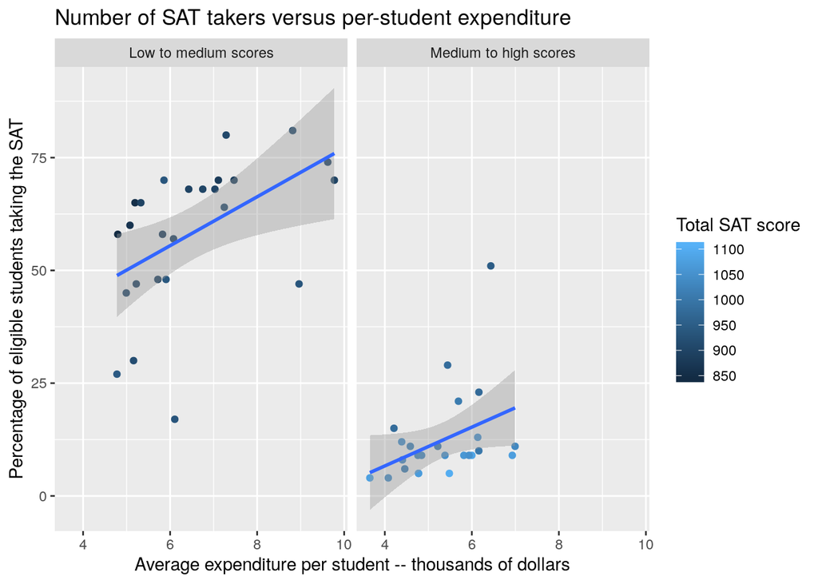

```r
hi_lo <- sat$total
hi_lo <- as.factor(hi_lo >=945.5)
hi_lo <- revalue(hi_lo, c("FALSE"="Low to medium scores", "TRUE"="Medium to high scores"))
sat$hi_lo <- hi_lo
ggplot(data=sat, aes(x=expend, y=takers, color=total)) + geom_point() + geom_smooth(method='lm') +
  facet_wrap(~hi_lo) +
  labs(
    x="Average expenditure per student -- thousands of dollars",
    y="Percentage of eligible students taking the SAT",
    title="Number of SAT takers versus per-student expenditure",
    color="Total SAT score"
  )
```

We note that separating the data into the upper and lower 50 percentile, we see that there is a consistent pattern where the percentage of eligible students taking the SAT increases with the average expenditure per student. Interestingly, the schools with the upper 50 percentile average on the SAT also largely have a significantly lower percentage of eligible students taking the SAT. In order to evaluate the impact of avearge expenditures per student, the data should be understood in terms of the large discepancy in the number of eligible students taking the exams between the two modes in the data.

##### Part 2:

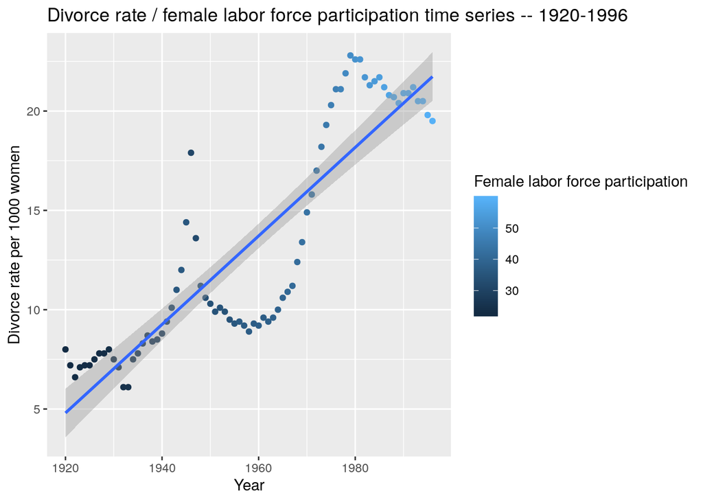

```r
ggplot(data=divusa, aes(x=year, y=divorce, color=femlab)) + geom_point() + geom_smooth(method='lm') +
  labs(
    x="Year",
    y="Divorce rate per 1000 women",
    title="Divorce rate / female labor force participation time series -- 1920-1996",
    color="Female labor force participation"
  )
```

We note that there is a trend over time of both higher divorce rates and female labor force participation. The trend in each case appears with some variation. Particularly, the divorce rate also appears to correlate strongly with several significant historical events in the USA: (i) the Great Depression; (ii) World War 2; (iii) the Baby Boom; (iv) 1960’s and 1970’s cultural movements.